# 第4回 線形回帰の評価プロトコルを実装し、結果を解釈する

## 前回からの接続

第3回は、民泊のホストとして、データを整えてから線形回帰（linear regression）の式を作り、1泊の値段を付けました。整えるたびに、テストでの平均絶対誤差（MAE）を測って比べました。

ただ、そのMAEは、訓練とテストへの分け方1通りで測った数でした。分け方を変えたら、数はどれくらい変わるのでしょうか。そして、式の係数が何を言っているのかは、まだ読んでいません。今日は、住宅の価格のデータで、式の評価と係数の解釈に取り組みます。

## 今日の分析目標

あなたは住宅の査定担当者です。お客さんに説明できる査定の式を、どう選ぶかに答える。

米国エイムズ市の住宅の売買2,412軒のデータで、価格を当てる線形回帰の式を作ります。式は、当たりの良さと、係数がお客さんへの説明に使えるかの2つの面から選び、1軒の家の査定書を書きます。

もう1つのねらいは、自分で書いた関数を部品にして、大きな関数を組み立てられるようになることです。誤差を測る関数を、分け方を何度も変えて評価する関数の中で呼び、その関数を列の組ごとに呼んで表に並べます。最後の「目標に答えられたか」で振り返りましょう。

### 場面

あなたは、米国アイオワ州エイムズ市の住宅の査定担当者です。家の条件（広さ・品質・建てた年など）から値段を見積もり、お客さんに伝えます。

お客さんは、値段だけでは納得しません。「なぜこの値段なのか」を、条件ごとに説明する必要があります。

### 手元のデータ

エイムズ市の資産評価事務所が記録した、2006〜2010年の住宅の売買2,930件です（De Cock, 2011）。1行が1軒の売買で、列は80本あります。答えの列は、その家が売れた価格（米ドル）です。

このうち、ふつうの売買で、広すぎない家に絞って使います（0節）。

### 最後に出す答え

査定に使う式と、それを選んだ理由です。そして、その式で書いた1軒の家の査定書です。査定書には、査定額・どれくらい外れうるか・平均的な家より高い（安い）理由を、条件ごとの金額で書きます。

## 学習ゴール

この回を終えると、次のことができるようになります。

- 平均絶対誤差（MAE）と二乗平均平方根誤差（RMSE）を関数にし、大きな誤差の扱いの違いを説明できる
- 線形回帰の係数を「ほかの列を同じにしたまま、その列を1増やすと、予測が何ドル変わるか」と読み、1列だけの式の係数と違う理由を説明できる
- 訓練とテストへの分け方を変えると、MAEも係数も揺れることを確かめ、似た2列が係数を不安定にすること（多重共線性）を説明できる
- 2つの式を比べるときに、同じ分け方どうしで並べる理由を説明できる
- 交差検証（cross-validation）で全部の行を1度ずつテストに回し、式を評価できる
- 関数を部品にして大きな関数を組み立て、1行を差し替えて別の評価の方法に変えられる
- f-stringで数を文の中に埋め込み、査定書の文を作れる

## 0. 準備

### 最初に実行する：道具を呼び出す

- 役割：このノートで使う道具（ライブラリ）を呼び出す
- 入力：なし
- 出力：なし（終わるとセルの左に ✓ が付く）

`import`は道具箱を持ってくる命令、`from`は道具箱から1つだけ取り出す書き方です。今日は、データの分け方を作る`KFold`が加わります（5節で使います）。

```python
import numpy as np
import pandas as pd
import matplotlib.pyplot as plt
from sklearn.linear_model import LinearRegression
from sklearn.model_selection import train_test_split, KFold
```

### 図の日本語を表示できるようにする

- 役割：図の中の日本語が □ にならないようにし、図の大きさと字の大きさをそろえる
- 入力：なし
- 出力：「セットアップ完了」の表示

`try:`から先は、日本語表示の道具が動かなくなったときの保険で、中身は読まなくてかまいません。

```python
# 日本語が図の中で □ になるのを防ぐ
!pip install -q japanize-matplotlib
try:
    import japanize_matplotlib
# japanize が動かなくなったときの保険：同梱フォントを直接登録する
except Exception:
    from importlib.util import find_spec
    from matplotlib import font_manager as fm
    from pathlib import Path
    spec = find_spec('japanize_matplotlib')
    ttf = None
    if spec:
        ttf = next(Path(spec.origin).parent.rglob('*.ttf'), None)
    if ttf:
        fm.fontManager.addfont(str(ttf))
        name = fm.FontProperties(fname=str(ttf)).get_name()
        plt.rcParams['font.family'] = name

plt.rcParams['figure.figsize'] = (9, 5)
plt.rcParams['font.size'] = 13
plt.rcParams['axes.unicode_minus'] = False  # マイナス記号の化けを防ぐ
print('セットアップ完了')
```

```
セットアップ完了
```

### お手本：表を読み込んで、列名を日本語にする

- 役割：CSVファイルの表を読み込み、今日使う列の名前を日本語に付け替えて、先頭5行を見る
- 入力：データの置き場所`DATA_DIR`と、ファイル名`ames_housing.csv`
- 出力：表`raw`（元の表）

第3回と同じく、`{'元の名前': '新しい名前', ...}`の辞書を`rename(columns=...)`に渡して、列名を付け替えます。80本のうち、今日使う13本だけを日本語にします。

```python
# データはこのリポジトリから読み込む
DATA_DIR = ('https://raw.githubusercontent.com/k0heiun0/'
            'applied_exercise_preview/main/shared/data')
raw = pd.read_csv(f'{DATA_DIR}/ames_housing.csv')
ja_names = {'Sale Condition': '売買の条件', 'SalePrice': '価格',
            'Overall Qual': '品質', 'Gr Liv Area': '居住面積',
            'Total Bsmt SF': '地下の面積',
            'Garage Cars': '車庫の台数', 'Garage Area': '車庫の面積',
            'Year Built': '建てた年', 'Year Remod/Add': '改装した年',
            'Full Bath': 'バスルーム数', 'TotRms AbvGrd': '部屋数',
            'Fireplaces': '暖炉の数', 'Lot Area': '敷地面積'}
raw = raw.rename(columns=ja_names)
raw[['品質', '居住面積', '車庫の台数', '売買の条件', '価格']].head()
```

|  | 品質 | 居住面積 | 車庫の台数 | 売買の条件 | 価格 |
| --- | --- | --- | --- | --- | --- |
| 0 | 6 | 1656 | 2.0 | Normal | 215000 |
| 1 | 5 | 896 | 1.0 | Normal | 105000 |
| 2 | 6 | 1329 | 1.0 | Normal | 172000 |
| 3 | 7 | 2110 | 2.0 | Normal | 244000 |
| 4 | 5 | 1629 | 2.0 | Normal | 189900 |

日本語にした列の中身は、次のとおりです。

| 日本語の名前 | 元の名前 | 中身 |
| --- | --- | --- |
| `売買の条件` | `Sale Condition` | ふつうの売買（`Normal`）・新築の売り出し・親族間の売買など |
| `価格` | `SalePrice` | 売れた価格（米ドル）。当てたい値 |
| `品質` | `Overall Qual` | 家全体の材料と仕上げの品質（1〜10の10段階） |
| `居住面積` | `Gr Liv Area` | 地上階の居住面積 |
| `地下の面積` | `Total Bsmt SF` | 地下室の面積 |
| `車庫の台数`・`車庫の面積` | `Garage Cars`・`Garage Area` | 車庫に入る車の台数と、車庫の面積 |
| `建てた年`・`改装した年` | `Year Built`・`Year Remod/Add` | 建てた年と、改装した年（改装していなければ建てた年） |
| `バスルーム数` | `Full Bath` | 地上階の、浴槽かシャワーのあるバスルームの数 |
| `部屋数` | `TotRms AbvGrd` | 地上階の部屋の数（バスルームを除く） |
| `暖炉の数` | `Fireplaces` | 暖炉の数 |
| `敷地面積` | `Lot Area` | 敷地の面積 |

面積の列は、元は平方フィート（1平方フィートは約0.0929㎡）です。

### 変えてみる：ふつうの売買に絞り、面積を㎡に直す

- 役割：ふつうの売買で、居住面積が4,000平方フィート以下の家に絞り、面積の列を㎡に直す
- 入力：表`raw`
- 出力：絞った表`df`と、その軒数・価格の要約

親族間の売買や、差し押さえの売買は、ふつうの値段の付き方と違います。居住面積が4,000平方フィート（約372㎡）を超える家は全体で5軒だけで、データの作者も、授業で使うなら外すよう勧めています。

`&`は「かつ」です（第3回のおさらい）。`for`文で、面積の4本の列に同じ計算（0.0929を掛ける）を順に当てます。

```python
normal = raw['売買の条件'] == 'Normal'     # ふつうの売買
small = raw['居住面積'] <= 4000            # 広すぎない家
df = raw[normal & small].reset_index(drop=True)
for c in ['居住面積', '地下の面積', '車庫の面積', '敷地面積']:
    df[c] = df[c] * 0.0929                 # 平方フィート → ㎡
print(len(df), '軒')
print(df['価格'].describe().round(0))
```

```
2412 軒
count      2412.0
mean     175327.0
std       70006.0
min       35000.0
25%      129500.0
50%      158750.0
75%      206225.0
max      625000.0
Name: 価格, dtype: float64
```

残ったのは2,412軒です。価格の平均は約17万5千ドル、中央値は約15万9千ドルで、最も安い家は3万5千ドル、最も高い家は62万5千ドルです。

### 手がかりにする11本の列

価格を当てる手がかりにする列の名前を、`feat`にしまっておきます。今日は、この11本の列をいろいろに選び直して、式を比べます。

```python
feat = ['品質', '居住面積', '地下の面積', '車庫の台数', '車庫の面積',
        '建てた年', '改装した年', 'バスルーム数', '部屋数',
        '暖炉の数', '敷地面積']
print(len(feat), '本')
```

```
11 本
```

### 分析の地図：今日はここ

データ解析は「① データの理解と目標の設定 → ② 前処理（preprocessing）とデータ解析 → ③ 結果の解釈と目標との整合」の3つのフェーズを回ります。今日は、②の評価と、③の解釈が中心です。

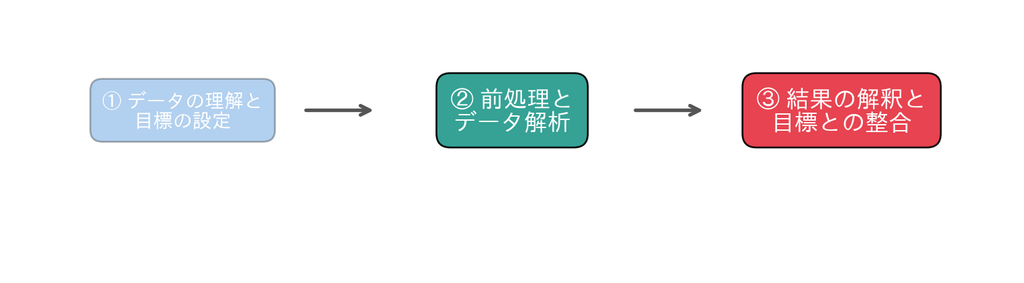

### 今日の道筋

次の6つの小さな問いに答えていきます。

1. 何ドル外れる？（1節）
2. 係数は何を言っている？（2節）
3. その数字、どこまで信じる？（3節）
4. 列を1本外すと？（4節）
5. 全部の行を1度ずつテストにするには？（5節）
6. どちらを外し、どう説明する？（6〜7節）

## 1. 何ドル外れる？

表が整いました。まず第2回と同じ手順で、訓練とテストに分けて線形回帰の式を作り、テストの家で当たり具合を測ります。

### お手本：分けて、式を作る

- 役割：家を訓練8割・テスト2割に分け、11本の列で価格を当てる式を作る
- 入力：表`df`と、列の名前`feat`
- 出力：訓練とテストの軒数と、テストでの決定係数（R²）

`m.score(テストの手がかり, テストの答え)`は、第2回で使った決定係数（coefficient of determination）R²を返します。今日は、分け方の乱数（random number）の種を`random_state=0`にします。

```python
tr, te = train_test_split(df, test_size=0.2, random_state=0)
m = LinearRegression().fit(tr[feat], tr['価格'])
print(len(tr), len(te))
print(round(m.score(te[feat], te['価格']), 3))   # テストのR²
```

```
1929 483
0.854
```

訓練1,929軒、テスト483軒で、テストでのR²は0.854です。価格のばらつきの8割以上を、式で説明できています。

R²は、どれだけ説明できたかの割合です。でも、査定担当として知りたいのは「何ドル外れるか」です。

### おさらい：MAEの関数

第3回で書いた、平均絶対誤差（MAE）の関数です。$y_i$は$i$番目の家の実際の価格、$\hat{y}_i$はその予測です。

$$\text{MAE} = \frac{1}{n}\sum_{i=1}^{n} \lvert y_i - \hat{y}_i \rvert$$

`def 名前(引数):`で関数を作り、`return`の後ろが戻り値です。作っただけでは何も出ないので、呼び出して使います。

```python
def mae(y, pred):          # MAE
    return round(np.abs(y - pred).mean())

pred = m.predict(te[feat])
print(mae(te['価格'], pred), 'ドル')
```

```
19391 ドル
```

テストの家での予測は、平均19,391ドル外れます。価格の中央値が約15万9千ドルなので、1割ほどです。

### お手本：大きな誤差を重く見る物差し（RMSE）

MAEは、誤差を大きさのまま平均します。5千ドルの誤差が10軒あっても、5万ドルの誤差が1軒と9軒の正解でも、MAEは同じ5千ドルです。でも、査定では、5万ドル外した1軒が、お客さんの信頼を大きく失わせます。

そこで、誤差を二乗してから平均し、最後に平方根で単位をドルに戻す物差しを使います。二乗平均平方根誤差（RMSE, root mean squared error）と呼びます。

$$\text{RMSE} = \sqrt{\frac{1}{n}\sum_{i=1}^{n} (y_i - \hat{y}_i)^2}$$

二乗すると、大きな誤差ほど、もっと大きくなります。RMSEは、大きな誤差を重く見る物差しです。

- 役割：実際の価格と予測から、RMSE（ドル）を出す
- 入力：実際の価格`y`と、予測`pred`
- 出力：RMSE（整数に丸めたドル）

`mae`との違いは1行目の中だけです。`** 2`は二乗、`np.sqrt`は平方根です。

```python
def rmse(y, pred):         # RMSE
    return round(np.sqrt(((y - pred) ** 2).mean()))

print(rmse(te['価格'], pred), 'ドル')
```

```
27191 ドル
```

RMSEは27,191ドルで、MAE（19,391ドル）より大きくなりました。RMSEは、いつもMAE以上になります。差が大きいほど、少数の大きな誤差が混ざっています。

### TODO①：5万ドル以上外した家を数える

テストの家のうち、予測が5万ドル以上外れた家は何軒あるでしょうか。誤差の大きさ`np.abs(te['価格'] - pred)`が50000以上の家の数と、誤差のいちばん大きな値を表示してください。

```python
# TODO: 誤差の大きさが 50000 以上の家の数と、誤差の最大値を表示する
# ヒント: err = np.abs(te['価格'] - pred) のあと、
#         (err >= 50000).sum() と err.max()
...;
```

483軒のうち28軒で、5万ドル以上外れています。いちばん大きな誤差は約20万ドル（200,677ドル）です。MAEだけを見ていると、こうした大きな誤差が見えません。このあとは、MAEとRMSEを並べて測ります。

## 2. 係数は何を言っている？

何ドル外れるかが分かりました。次は、お客さんへの説明です。この式は、価格について何を言っているのでしょうか。式の係数を読みます。

### 係数の読み方

線形回帰の式は、11本の列$x_{i1}, \dots, x_{i11}$に係数$b_1, \dots, b_{11}$を掛けて足し、切片$b_0$を加えたものです。

$$\hat{y}_i = b_0 + b_1 x_{i1} + b_2 x_{i2} + \cdots + b_{11} x_{i11}$$

ほかの列の値を全部そのままにして、$x_{ij}$だけを1増やすと、予測$\hat{y}_i$は$b_j$だけ変わります。係数$b_j$は「ほかの列を同じにしたまま、その列を1増やすと、予測が何ドル変わるか」です。

### お手本：係数を、列の名前と並べる

- 役割：1節の式`m`の係数を、列の名前と並べて表示する
- 入力：1節の式`m`
- 出力：列ごとの係数（ドル）

`m.coef_`には、係数が`feat`と同じ順に並んでいます。`pd.Series(値の並び, index=名前の並び)`で、名前の付いた1列の表にします。名前が付くと、`coef['品質']`のように名前で取り出せます。

```python
coef = pd.Series(m.coef_, index=feat)
print(coef.round(0))
```

```
品質        16065.0
居住面積        675.0
地下の面積       369.0
車庫の台数       267.0
車庫の面積       379.0
建てた年        286.0
改装した年       354.0
バスルーム数    -9976.0
部屋数       -3333.0
暖炉の数       8548.0
敷地面積         11.0
dtype: float64
```

例えば品質は16,065ドルです。「ほかの条件が同じなら、品質が1段階上がると、予測が約1万6千ドル上がる」と読みます。居住面積は675ドルで、「ほかが同じなら、居住面積が1㎡広いと675ドル高い」です。暖炉の数は8,548ドルです。

一方で、気になる係数が2つあります。車庫の台数は267ドルです。車庫に車がもう1台入っても、たった267ドルしか上がらないのでしょうか。そして、バスルーム数は−9,976ドルです。バスルームが1つ多いと、約1万ドル安くなるのでしょうか。

### 変えてみる：バスルーム数だけの式

- 役割：バスルーム数だけで価格を当てる式の係数と、バスルーム数・居住面積・部屋数の相関を見る
- 入力：訓練の表`tr`
- 出力：1列だけの式の係数と、3つの列の相関係数の表

`corr()`は、列どうしの相関係数を表にします。

```python
m_bath = LinearRegression().fit(tr[['バスルーム数']], tr['価格'])
print(round(m_bath.coef_[0]), 'ドル')
print(tr[['バスルーム数', '居住面積', '部屋数']].corr().round(2))
```

```
68759 ドル
        バスルーム数  居住面積   部屋数
バスルーム数    1.00  0.64  0.53
居住面積      0.64  1.00  0.80
部屋数       0.53  0.80  1.00
```

バスルーム数だけの式では、係数は68,759ドルです。バスルームが多い家は、高いのです。

バスルーム数と居住面積の相関は0.64、部屋数との相関は0.53です。バスルームの多い家は、たいてい広くて部屋も多い家です。1列だけの式の68,759ドルには、「広くて部屋も多い」ことの分まで入っています。

11本の式の−9,976ドルは、意味が違います。居住面積と部屋数を同じにしたまま、バスルームだけを1つ増やすと、という比較です。同じ広さでバスルームが1つ多いなら、そのぶんほかの部屋が狭くなります。「バスルームが多い家は安い」ではなく、「同じ広さなら、バスルームに面積を割いた家は、少し安い」です。

係数は、一緒に入れた列によって意味が変わります。いつも「ほかの列を同じにしたら」を付けて読みます。

## 3. その数字、どこまで信じる？

係数が読めるようになりました。ただ、1節のMAEも2節の係数も、`random_state=0`という1通りの分け方で出した数です。分け方を変えたら、同じ数が出るのでしょうか。

### おさらい：for文

`for 変数 in 並び:`は、並びの中身を1つずつ変数に入れて、字下げした行をくり返します。`range(20)`は0から19までの20個の数です。

```python
for s in range(3):
    print(s)          # 0, 1, 2 と順に表示される
```

### お手本：分け方を20通り変える

- 役割：`random_state`を0〜19に変えて分け直し、毎回、式を作ってMAEと車庫の台数の係数をためる
- 入力：表`df`と、列の名前`feat`
- 出力：20回分の結果の表`result`の要約と、係数がマイナスになった回数

`rows = []`で空のリストを作り、毎回の結果を辞書`{'名前': 値, ...}`にして`rows.append(...)`で1行ずつ足します。最後に`pd.DataFrame(rows)`で、20行の表にします。

ループの中の訓練とテストは、1節の`tr`・`te`を上書きしないよう、`tr_s`・`te_s`という名前にします。

```python
rows = []
for s in range(20):
    tr_s, te_s = train_test_split(df, test_size=0.2, random_state=s)
    m_s = LinearRegression().fit(tr_s[feat], tr_s['価格'])
    coef_s = pd.Series(m_s.coef_, index=feat)
    rows.append({'MAE': mae(te_s['価格'], m_s.predict(te_s[feat])),
                 '車庫の台数': round(coef_s['車庫の台数'])})
result = pd.DataFrame(rows)
print(result.describe().round(0))
print((result['車庫の台数'] < 0).sum(), '回はマイナス')
```

```
           MAE   車庫の台数
count     20.0    20.0
mean   19367.0    -3.0
std      535.0  1035.0
min    18555.0 -2081.0
25%    19042.0  -712.0
50%    19382.0   198.0
75%    19604.0   461.0
max    20874.0  2143.0
8 回はマイナス
```

MAEは、最小18,555ドルから最大20,874ドルまで、分け方だけで2,300ドルほど揺れます。平均は19,367ドルです。1節の19,391ドルは、この20通りのうちの1つ（`random_state=0`）にすぎません。どの分け方を引くかで、報告する数が変わってしまいます。

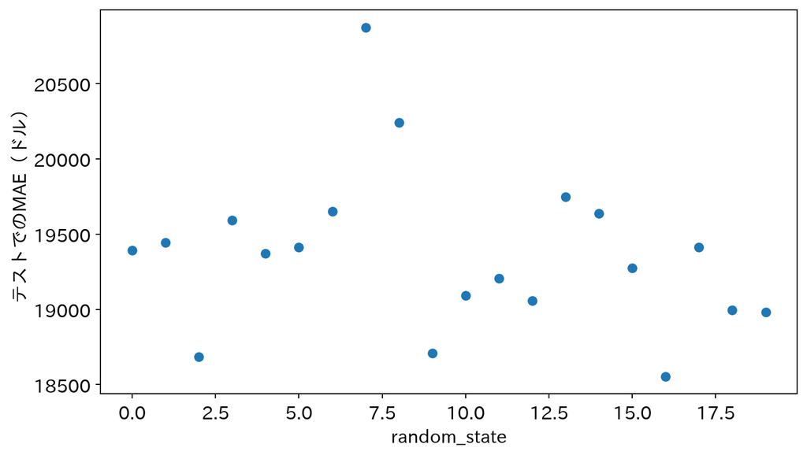

```python
plt.plot(result['MAE'], 'o')
plt.xlabel('random_state')
plt.ylabel('テストでのMAE（ドル）')
plt.show()
```

### 係数は、符号まで揺れる

車庫の台数の係数は、もっと揺れます。最小−2,081ドルから最大2,143ドルまで、20回のうち8回はマイナスです。分け方しだいで、「車庫に車がもう1台入ると、高くなる」とも「安くなる」とも読めてしまいます。これでは、お客さんに説明できません。

### お手本：車庫の台数と車庫の面積の相関

- 役割：車庫の台数と車庫の面積の相関係数を出す
- 入力：表`df`
- 出力：相関係数

```python
print(round(df['車庫の台数'].corr(df['車庫の面積']), 2))
```

```
0.89
```

相関係数は0.89です。車が何台入るかは、ほぼ車庫の広さで決まります。2つの列が、ほとんど同じことを言っているのです。

こうした似た2列を一緒に式に入れると、2つの係数の「和」はデータで決まっても、どちらにどれだけ割り振るかの「内訳」が決まりません。台数に多く割り振っても、面積に多く割り振っても、予測はほとんど変わらないからです。訓練に入る家が少し入れ替わるだけで、内訳が大きく動き、係数の符号まで変わります。

似た列が式の中にあって係数が不安定になることを、多重共線性（multicollinearity）と呼びます。

## 4. 列を1本外すと？

車庫の台数の係数が揺れるのは、よく似た車庫の面積が一緒に入っているからでした。それなら、車庫の面積を外せば、台数の係数は落ち着くはずです。ただ、手がかりを1本減らすと、当たりは悪くならないでしょうか。3節と同じ20回の評価を、列を変えてもう1度やります。

### お手本：20回の評価を関数にする

3節のセルを、列の組を変えてもう1度書くのは手間です。くり返しになったところで、関数にまとめます。

- 役割：分け方を20通り変えて式を作り、毎回のMAE・RMSE・指定した列の係数をためた表を返す
- 入力：手がかりの列の名前`cols`、係数を見る列`watch`（既定値は`'車庫の台数'`）
- 出力：20行の表（列はMAE・RMSE・係数）

中身は3節のセルとほぼ同じです。違いは3つです。`feat`を引数`cols`に変えたこと、1節の`rmse`も呼ぶようにしたこと、係数を見る列を引数`watch`で選べるようにしたことです。1節で作った`mae`と`rmse`を、この関数の中で部品として呼んでいます。

```python
def split_scores(cols, watch='車庫の台数'):
    rows = []
    for s in range(20):
        tr_s, te_s = train_test_split(df, test_size=0.2,
                                      random_state=s)
        m_s = LinearRegression().fit(tr_s[cols], tr_s['価格'])
        pred_s = m_s.predict(te_s[cols])
        coef_s = pd.Series(m_s.coef_, index=cols)
        rows.append({'MAE': mae(te_s['価格'], pred_s),
                     'RMSE': rmse(te_s['価格'], pred_s),
                     '係数': round(coef_s[watch])})
    return pd.DataFrame(rows)

all11 = split_scores(feat)
print(all11.mean().round(0))
```

```
MAE     19367.0
RMSE    27060.0
係数         -3.0
dtype: float64
```

MAEの平均は19,367ドルで、3節と同じです。同じ20通りの分け方で、同じ式を作っているからです。関数にまとめても、結果は変わりません。

### 変えてみる：車庫の面積を外す

- 役割：車庫の面積を外した10本の列で、同じ20回の評価をする
- 入力：列の名前`no_area`
- 出力：20回の結果の要約

```python
no_area = ['品質', '居住面積', '地下の面積', '車庫の台数',
           '建てた年', '改装した年', 'バスルーム数', '部屋数',
           '暖炉の数', '敷地面積']
drop_area = split_scores(no_area)
print(drop_area.describe().round(0))
```

```
           MAE     RMSE      係数
count     20.0     20.0    20.0
mean   19651.0  27317.0  8543.0
std      562.0   1375.0   574.0
min    18730.0  25182.0  7392.0
25%    19359.0  26401.0  8339.0
50%    19582.0  27108.0  8450.0
75%    19852.0  28023.0  8772.0
max    21215.0  29923.0  9801.0
```

車庫の台数の係数は、最小7,392ドルから最大9,801ドルで、20回とも約8千〜1万ドルのプラスに落ち着きました。「車庫に車がもう1台入ると、約8千ドル高い」と説明できます。

MAEの平均は19,651ドルで、11本の式（19,367ドル）より284ドル悪くなりました。

### 問い：284ドルの差は、揺れの中に埋もれていないか

MAEは、分け方だけで2,300ドルほど揺れました。それに比べて、284ドルの差はずっと小さな差です。面積を外した式が本当に悪いのか、たまたまなのか、どうやって確かめればよいでしょうか。予想を下に書いてください。

（ここに予想を書く）

### お手本：同じ分け方どうしで並べる

- 役割：20回それぞれで、11本の式と面積を外した式のMAEを横に並べ、差を出す
- 入力：`split_scores`の2つの結果`all11`と`drop_area`
- 出力：20行の比較の表と、面積を外した式が悪かった回数

`random_state`が同じ回どうしは、テストの家がまったく同じです。同じ家で測った2つのMAEなら、差は式の違いだけから生まれます。

```python
compare = pd.DataFrame({'11本': all11['MAE'],
                        '面積を外す': drop_area['MAE']})
compare['差'] = compare['面積を外す'] - compare['11本']
print(compare)
print((compare['差'] > 0).sum(), '回は面積を外すと悪い')
```

```
      11本  面積を外す    差
0   19391  19634  243
1   19445  19720  275
2   18685  18741   56
3   19593  19838  245
4   19372  19743  371
5   19414  19534  120
6   19652  19892  240
7   20874  21215  341
8   20241  20522  281
9   18710  19179  469
10  19091  19259  168
11  19205  19550  345
12  19057  19365  308
13  19748  20206  458
14  19637  19935  298
15  19273  19615  342
16  18555  18730  175
17  19413  19463   50
18  18995  19542  547
19  18980  19342  362
20 回は面積を外すと悪い
```

20回すべてで、面積を外した式のほうが悪くなりました。差は、最も小さい回で50ドル、最も大きい回で547ドルです。MAEそのものは分け方で大きく揺れますが、同じ分け方どうしの差は、いつも同じ向きです。

逆に、違う分け方どうしで比べると、結論が逆になります。例えば、面積を外した式の`random_state=16`（18,730ドル）と、11本の式の`random_state=7`（20,874ドル）を比べると、面積を外した式のほうが2千ドル以上も良く見えます。テストの家が違えば、当てやすい家に当たったかどうかで、MAEが変わるからです。式を比べるときは、同じ分け方どうしで並べます。

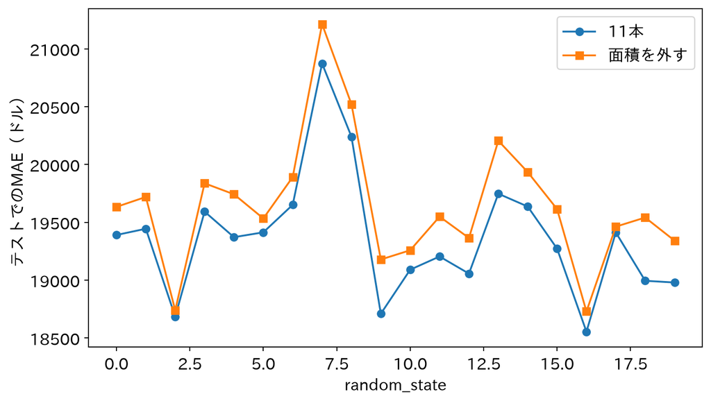

```python
plt.plot(compare['11本'], 'o-', label='11本')
plt.plot(compare['面積を外す'], 's-', label='面積を外す')
plt.xlabel('random_state')
plt.ylabel('テストでのMAE（ドル）')
plt.legend()
plt.show()
```

2本の線は、分け方ごとに一緒に上がったり下がったりします。そして、どの分け方でも、面積を外した式（四角）が少し上にあります。

これで、板ばさみがはっきりしました。面積を外すと、係数は説明に使えるのに、当たりは確かに少し悪くなります。

## 5. 全部の行を1度ずつテストに

同じ分け方どうしで並べれば、式を比べられることが分かりました。ただ、20回の分け直しには、まだ気になる点があります。それぞれの家は、20回のうち何回テストに入ったのでしょうか。

### お手本：家ごとに、テストに入った回数を数える

- 役割：20回の分け方それぞれで、テストに入った家に1を足していき、家ごとの回数を数える
- 入力：表`df`
- 出力：「テストに入った回数」ごとの家の数

`pd.Series(0, index=df.index)`で、家の数だけ0を並べた入れ物を作ります。`count[te_s.index] += 1`は、その回にテストに入った家（`te_s.index`の行）にだけ1を足します。`value_counts()`は値ごとの数、`sort_index()`はそれを回数の小さい順に並べます。

```python
count = pd.Series(0, index=df.index)
for s in range(20):
    tr_s, te_s = train_test_split(df, test_size=0.2, random_state=s)
    count[te_s.index] += 1
print(count.value_counts().sort_index())
```

```
0      29
1     120
2     337
3     489
4     545
5     435
6     249
7     137
8      51
9      17
10      3
Name: count, dtype: int64
```

20回で1度もテストに入らなかった家が29軒あります。一方で、10回もテストに入った家が3軒あります。20回のMAEの平均は、何度もテストに入った家ほど重く数え、1度も入らなかった家は数えていないことになります。

どの家も、ちょうど1度ずつテストに入るように分けられないでしょうか。

### 交差検証：全部の行を1度ずつテストにする

家を、重ならない5つの組に分けます。1回目は1つ目の組をテストに、残りの4組を訓練にして、式を作ってMAEを測ります。2回目は2つ目の組をテストに……と、5回くり返します。5回で、どの家もちょうど1度ずつテストに入ります。最後に、5回のMAEを平均します。

$$\text{CV} = \frac{1}{K}\sum_{k=1}^{K} \text{MAE}_k$$

$K$は組の数（今日は5）、$\text{MAE}_k$は$k$番目の組をテストにしたときのMAEです。このやり方を、$K$分割交差検証（K-fold cross-validation, CV）と呼びます。

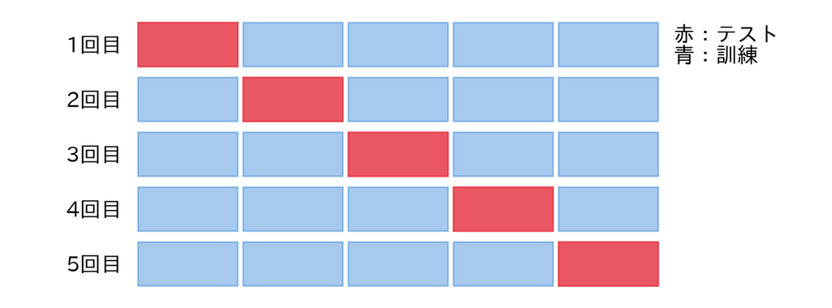

### お手本：5つの組を作る

- 役割：家を5つの組に分ける道具を作り、5回分の訓練とテストの行番号を確かめる
- 入力：表`df`
- 出力：各回の訓練とテストの軒数と、テストに入った家の最初の5つの行番号

`KFold(n_splits=5, shuffle=True, random_state=0)`は、行を混ぜてから5つの組に分ける道具です。`kf.split(df)`は、5回分の「訓練の行番号の並び」と「テストの行番号の並び」の組を、`for`文で1回ずつ渡します。

```python
kf = KFold(n_splits=5, shuffle=True, random_state=0)
for tr_i, te_i in kf.split(df):
    print(len(tr_i), len(te_i), te_i[:5])
```

```
1929 483 [ 1  9 10 11 14]
1929 483 [ 4  5  6 15 19]
1930 482 [ 2  8 13 16 29]
1930 482 [12 20 21 28 38]
1930 482 [ 0  3  7 24 25]
```

5回とも、訓練が1,929軒か1,930軒、テストが483軒か482軒です。テストに入る家は、回ごとに入れ替わります。

`tr_i`と`te_i`は行番号の並びです。表から、その行番号の行を取り出すには`df.iloc[行番号の並び]`を使います。`iloc`は、行の番号（0から数えた位置）で行を取り出す書き方です。

### お手本：交差検証の関数

- 役割：5分割の交差検証で、毎回のMAE・RMSE・指定した列の係数をためた表を返す
- 入力：手がかりの列の名前`cols`、係数を見る列`watch`（既定値は`'車庫の台数'`）
- 出力：5行の表（列はMAE・RMSE・係数）

4節の`split_scores`と比べてください。変わったのは、`for`の行と、その次の訓練とテストを作る行の2行だけです。「分け方」の部品を差し替えるだけで、20回の分け直しが交差検証に変わります。

```python
def cv_score(cols, watch='車庫の台数'):
    rows = []
    for tr_i, te_i in kf.split(df):
        tr_s, te_s = df.iloc[tr_i], df.iloc[te_i]
        m_s = LinearRegression().fit(tr_s[cols], tr_s['価格'])
        pred_s = m_s.predict(te_s[cols])
        coef_s = pd.Series(m_s.coef_, index=cols)
        rows.append({'MAE': mae(te_s['価格'], pred_s),
                     'RMSE': rmse(te_s['価格'], pred_s),
                     '係数': round(coef_s[watch])})
    return pd.DataFrame(rows)

cv11 = cv_score(feat)
print(cv11)
print(cv11.mean().round(0))
```

```
     MAE   RMSE    係数
0  19391  27191   267
1  19459  27354  -650
2  19404  27144  -240
3  18862  26754 -1032
4  19368  26540  -397
MAE     19297.0
RMSE    26997.0
係数       -410.0
dtype: float64
```

5回のMAEは18,862〜19,459ドルで、平均は19,297ドルです。RMSEの平均は26,997ドルです。1回目は19,391ドルで、1節と同じ数です。`KFold`と`train_test_split`に同じ`random_state=0`を渡したので、1回目のテストの組が、1節のテストとたまたま同じ483軒になりました。

車庫の台数の係数は、交差検証でも267ドルから−1,032ドルまで揺れ、5回のうち4回はマイナスです。

### TODO②：面積を外した式も、交差検証で比べる

`cv_score`に、4節の`no_area`を渡して、面積を外した式の5回分の結果を出してください。そのうえで、11本の式（`cv11`）とMAEを横に並べた表を作り、5回のうち何回、面積を外した式のほうが悪かったかを表示してください。

```python
# TODO: cv_score(no_area) の結果と cv11 の MAE を並べて比べる
# ヒント: cv_area = cv_score(no_area) のあと、4節の compare と同じ形で
#         cv11['MAE'] と cv_area['MAE'] を並べた表を作る
...;
```

面積を外した式のMAEは平均19,561ドルで、5回すべてで11本の式より悪くなります。交差検証でも、4節と同じ結論です。

交差検証は、どの家もちょうど1度ずつテストに入るので、家の偏りなく式を評価できます。そして、2つの式を同じ5つの組で評価するので、いつも同じ分け方どうしで並べて比べられます。式を比べるときの、標準の物差しです。

## 6. どちらを外す？

交差検証で確かめても、車庫の面積を外すと当たりは悪くなりました。でも、似た2列のうち、外せるのは面積だけではありません。台数のほうを外したら、どうなるでしょうか。

### TODO③：車庫の台数を外して、交差検証で評価する

車庫の台数を外した10本の列の名前`no_cars`を作り、`cv_score`で評価してください。台数を外したので、係数は車庫の面積の係数を見ます（`watch='車庫の面積'`）。5回分の表と、その平均を表示してください。

```python
# TODO: 車庫の台数を外した列の組 no_cars を作り、cv_score で評価する
# ヒント: no_cars は feat から '車庫の台数' を除いた10本。
#         cv_score(no_cars, watch='車庫の面積')
...;
```

### お手本：3つの式を、1つの表に並べる

- 役割：11本の式・面積を外した式・台数を外した式を、同じ交差検証で評価し、平均を1つの表に並べる
- 入力：3つの列の組
- 出力：式ごとのMAE・RMSE・係数の平均

`cv_score(...).mean()`は、5回分の表の列ごとの平均です。それを辞書の値にして`pd.DataFrame`に渡すと、式ごとに1列の表になります。係数の行は、11本と面積を外した式では車庫の台数、台数を外した式では車庫の面積の係数です。

```python
no_cars = ['品質', '居住面積', '地下の面積', '車庫の面積',
           '建てた年', '改装した年', 'バスルーム数', '部屋数',
           '暖炉の数', '敷地面積']
table = pd.DataFrame({
    '11本': cv_score(feat).mean(),
    '面積を外す': cv_score(no_area).mean(),
    '台数を外す': cv_score(no_cars, watch='車庫の面積').mean()})
print(table.round(0))
```

```
          11本    面積を外す    台数を外す
MAE   19297.0  19561.0  19297.0
RMSE  26997.0  27219.0  26994.0
係数     -410.0   8416.0    390.0
```

台数を外した式のMAEは19,297ドルで、11本の式と同じです。RMSEも26,994ドルで、11本の式（26,997ドル）とほとんど変わりません。車庫の台数を外しても、当たりは落ちないのです。

車庫の面積の係数は、平均で1㎡あたり390ドルです。

```python
cv_cars = cv_score(no_cars, watch='車庫の面積')
print(cv_cars)
```

```
     MAE   RMSE   係数
0  19386  27188  387
1  19458  27352  394
2  19408  27145  375
3  18862  26744  390
4  19369  26540  402
```

5回とも、車庫の面積の係数は1㎡あたり375〜402ドルのプラスで、ほとんど揺れません。MAEも、5回それぞれで11本の式とほぼ同じです（1回目は19,386ドル、11本は19,391ドル）。

なぜ、台数を外しても当たりが落ちないのでしょうか。車庫の台数ごとに、車庫の面積の平均を見ます。

```python
print(df.groupby('車庫の台数')['車庫の面積'].mean().round(0))
```

```
車庫の台数
0.0      0.0
1.0     28.0
2.0     48.0
3.0     74.0
4.0     92.0
5.0    110.0
Name: 車庫の面積, dtype: float64
```

車1台の車庫は平均28㎡、2台は48㎡、3台は74㎡です。台数が1台増えると、面積は20〜26㎡ほど増えます。車庫の面積が、台数の情報をほとんど持っているのです。1㎡あたり390ドルなら、20〜26㎡で約8千〜1万ドルで、4節で面積を外したときの台数の係数（約8千〜1万ドル）とほぼ同じ大きさです。

反対に、台数は面積の情報を全部は持っていません。同じ2台用でも、広い車庫と狭い車庫があるからです。だから、面積を外すと当たりが少し落ち、台数を外しても落ちませんでした。

似た2列のどちらを残すかは、交差検証で比べて決めます。今日の査定には、車庫の台数を外した10本の式を使います。当たりは11本の式と同じで、係数は揺れずに読めます。

## 7. この家は、なぜこの値段？

査定に使う式が決まりました。いよいよ、1軒の家の査定書を書きます。

### お手本：選んだ式を、全部の家で作り直す

- 役割：台数を外した10本の列で、2,412軒すべてを使って式を作り直し、係数を表示する
- 入力：表`df`と、列の名前`no_cars`
- 出力：列ごとの係数

交差検証は、式を選ぶための評価でした。選んだら、手元の家を全部使って、査定に使う式を作り直します。家が多いほど、係数は安定するからです。当たりの目安には、交差検証のMAE（19,297ドル）を使います。

```python
final = LinearRegression().fit(df[no_cars], df['価格'])
coef_f = pd.Series(final.coef_, index=no_cars)
print(coef_f.round(0))
```

```
品質        15803.0
居住面積        686.0
地下の面積       371.0
車庫の面積       391.0
建てた年        297.0
改装した年       352.0
バスルーム数   -10245.0
部屋数       -3273.0
暖炉の数       8009.0
敷地面積          8.0
dtype: float64
```

品質は1段階で15,803ドル、居住面積は1㎡で686ドル、車庫の面積は1㎡で391ドルです。バスルーム数は−10,245ドルで、2節と同じく「同じ広さなら、バスルームに面積を割いた家は少し安い」です。

### 予測を、条件ごとの金額に分ける

査定書では、「平均的な家より、なぜ高い（安い）のか」を説明します。

式の予測$\hat{y}$から、平均的な家（どの列も2,412軒の平均$\bar{x}_j$）の予測を引くと、切片が消えて、列ごとの金額の和になります。

$$\hat{y} - \hat{y}_{\text{平均的な家}} = \sum_j b_j (x_j - \bar{x}_j)$$

$b_j(x_j - \bar{x}_j)$が、列$j$がこの家を平均よりいくら押し上げたか（マイナスなら押し下げたか）です。

### お手本：1軒目の家の内訳

- 役割：1軒目の家の予測と、平均的な家の予測、列ごとの押し上げを出す
- 入力：選んだ式`final`と係数`coef_f`、1軒目の家
- 出力：予測・平均的な家の予測・その差、家の条件の一部、列ごとの押し上げ

`df.iloc[[0]]`は、0行目の家を1行の表のまま取り出します（かっこを二重にすると表のまま）。`house.iloc[0]`は、その1行を列の名前の付いた並びにします。係数と同じく列の名前が付いているので、`coef_f * (家の値 - 平均)`は列どうしで掛け算されます。

```python
house = df.iloc[[0]]
pred_h = final.predict(house[no_cars])[0]
avg_h = final.predict(df[no_cars]).mean()   # 平均的な家の予測
push = coef_f * (house[no_cars].iloc[0] - df[no_cars].mean())
print(round(pred_h), round(avg_h), round(pred_h - avg_h))
print(house[['敷地面積', '暖炉の数', '建てた年', '改装した年']])
print(push.round(0))
```

```
211548 175327 36221
       敷地面積  暖炉の数  建てた年  改装した年
0  2951.433     2  1960   1960
品質         -111.0
居住面積      11463.0
地下の面積      1988.0
車庫の面積      2428.0
建てた年      -2799.0
改装した年     -8195.0
バスルーム数     5518.0
部屋数       -2078.0
暖炉の数      11193.0
敷地面積      16815.0
dtype: float64
```

1軒目の家の予測は211,548ドル、平均的な家の予測は175,327ドルです。差の36,221ドルを、列ごとの押し上げに分けました。

敷地面積が16,815ドル、居住面積が11,463ドル、暖炉の数が11,193ドルの押し上げです。この家は、敷地が約2,951㎡と広く、暖炉が2つあります。一方で、改装した年は−8,195ドルの押し下げです。1960年に建てたまま、改装していないからです。

### 問い：バスルームが少ないのに、押し上げ？

バスルーム数の押し上げは、+5,518ドルです。この家のバスルームは1つで、平均より少ないのに、値段を押し上げています。お客さんに「バスルームが少ないので高くなりました」と書いてよいでしょうか。予想を下に書いてください。

（ここに予想を書く）

そう書くと、お客さんは混乱します。バスルーム数の係数は「居住面積と部屋数を同じにしたら」の値でした。この家は、居住面積が平均より広いのに、バスルームが1つしかありません。そのぶん、ほかの部屋に面積を回している、という意味です。

バスルーム数は、居住面積・部屋数と似た列で、3つで「広さと間取り」を表しています。こうした列は、1つずつ説明せず、合わせて読みます。居住面積（+11,463ドル）・バスルーム数（+5,518ドル）・部屋数（−2,078ドル）を足すと、「広さと間取り」で+14,903ドルです。

### お手本：査定書の文を作る

- 役割：予測・交差検証のMAE・押し上げを、査定書の文にして表示する
- 入力：1軒目の家の予測`pred_h`、平均的な家の予測`avg_h`、押し上げ`push`
- 出力：査定書の文（5行）

先に、文に入れる金額を短い名前の変数にしておきます（`space`・`land`など）。

文字の前に`f`を付けた`f'...'`（f-string）の中では、`{ }`で囲んだところに、変数や計算の値が入ります。`{ }`の中の`:`の後ろは、数の書き方の指定です。

- `{pred_h:,.0f}`：3けたごとにカンマを入れ（`,`）、小数点以下0けた（`.0f`）で書く
- `{space:+,.0f}`：さらに、プラスのときも`+`を付ける（`+`）

```python
space = push['居住面積'] + push['バスルーム数'] + push['部屋数']
land = push['敷地面積']
fire = push['暖炉の数']
remod = push['改装した年']
cv_err = round(cv_score(no_cars, watch='車庫の面積')['MAE'].mean())
print(f'査定額：{pred_h:,.0f}ドル')
print(f'似た家での誤差は、平均{cv_err:,}ドルほどです。')
print(f'平均的な家（{avg_h:,.0f}ドル）より{pred_h - avg_h:+,.0f}ドル')
print(f'広さと間取り{space:+,.0f}ドル、敷地{land:+,.0f}ドル')
print(f'暖炉{fire:+,.0f}ドル、改装していないこと{remod:+,.0f}ドル')
```

```
査定額：211,548ドル
似た家での誤差は、平均19,297ドルほどです。
平均的な家（175,327ドル）より+36,221ドル
広さと間取り+14,903ドル、敷地+16,815ドル
暖炉+11,193ドル、改装していないこと-8,195ドル
```

査定書の文ができました。数を手で書き写さずに、計算した値をそのまま文に入れるので、式を作り直しても文がずれません。誤差の目安`cv_err`も、6節の交差検証をもう1度呼んで出しています。

### TODO④：別の家の査定書

1軒目の代わりに、`df.iloc[[5]]`（6軒目の家）の査定書を作ってください。お手本の「1軒目の家の内訳」と「査定書の文」の2つのセルを写し、`house = df.iloc[[0]]`の`0`を`5`に変えるだけで動きます。押し上げの大きい列を見て、査定書の最後の2行に書く列を選び直してみましょう。

```python
# TODO: 6軒目の家（df.iloc[[5]]）の押し上げと査定書の文を表示する
# ヒント: house = df.iloc[[5]] にして、お手本の2つのセルを写す。
#         print(push.round(0)) で押し上げの大きい列を確かめる
...;
```

6軒目の家の予測は190,365ドルで、実際の価格は195,500ドルでした。平均的な家より15,037ドル高く、いちばん押し上げているのは建てた年（+8,485ドル）と居住面積（+8,147ドル）です。

### 答え

査定には、車庫の台数を外した10本の列の線形回帰を使います。5分割の交差検証でMAEは19,297ドルで、11本の式と同じ当たりです。そのうえで、車庫の面積の係数は1㎡あたり375〜402ドルと揺れず、お客さんに「ほかの条件が同じなら」と説明できます。

1軒目の家の査定額は211,548ドルで、平均的な家より36,221ドル高い値段です。広さと間取り・広い敷地・2つの暖炉が押し上げ、改装していないことが押し下げています。

まだ言えないこと

- 列を外さずに係数を落ち着かせる方法：似た列を外すと、その列の情報（同じ2台用でも広い車庫と狭い車庫の違いなど）は捨てることになる
- 誤差の幅は家ごとに違う：交差検証のMAEは家全体の平均で、高い家ほど大きく外れやすい
- 列の選び方：今日は11本から1本ずつ外して比べた。手がかりになる列はほかにも70本近くある

## 目標に答えられたか

- 今日の目標は「お客さんに説明できる査定の式を、どう選ぶか」でした。選んだ式と、選んだ理由を2つの面から説明できますか？
- 1節で、MAEとRMSEはどう違いましたか？ 5万ドル以上外した家は何軒ありましたか？
- 2節で、バスルーム数の係数が、1列だけの式と11本の式で逆の符号になったのはなぜですか？
- 3節で、分け方を変えると、MAEと車庫の台数の係数はどれくらい揺れましたか？ 係数が揺れる理由は何でしたか？
- 4節で、2つの式を比べるときに、同じ分け方どうしで並べたのはなぜですか？
- 5節の交差検証は、20回の分け直しと比べて、何が良いのでしょうか？
- 7節の査定書で、バスルーム数をほかの列と合わせて読んだのはなぜですか？

## 今日の要点

- 今日、持ち帰る1文：式は2つの面から選ぶ。1つは、交差検証で同じ分け方どうしを並べた当たりの良さ。もう1つは、係数が「ほかの列を同じにしたら」の値として、揺れずに読めるかどうか
- MAEは誤差の大きさの平均、RMSEは大きな誤差を重く見る物差し。RMSEはいつもMAE以上
- 係数は「ほかの列を同じにしたまま、その列を1増やすと、予測が何ドル変わるか」。一緒に入れた列によって意味が変わる
- 1回の分け方の数は揺れる。MAEは分け方だけで2,300ドルほど動き、似た列の係数は符号まで変わる（多重共線性）
- 2つの式は、同じ分け方どうしで並べて比べる。違う分け方どうしでは、結論が逆にもなる
- 交差検証は、全部の行を1度ずつテストに回す。式を比べるときの標準の物差し
- 似た2列のどちらを残すかは、交差検証で比べて決める。似た列どうしは、合わせて読む
- Python：小さな関数（`mae`・`rmse`）を部品にして大きな関数（`split_scores`・`cv_score`）を組み立て、「分け方」の行を差し替えて評価の方法を変える。f-stringで数を文に埋め込む

## 次回へ

今日は、似た2列の片方を外して、係数を説明に使える形にしました。ただ、外した列の情報は捨てています。手がかりの列を増やすほど、似た列も増えていきます。

次回の問いは、列を増やして当たりを良くしながら、お客さんに説明できる係数を保てるか、です。

## 課題（提出）

提出するもの：応用②の答えと、応用③の文章。提出フォームに入力してください。期限はありません。応用①のコードは提出しませんが、②の答えを出すために必要です。

### 応用①（変形）

7節の査定書では、居住面積・バスルーム数・部屋数を「広さと間取り」として合わせて読みました。部屋数の係数も、査定に使った式ではマイナスです。では、部屋数を外したらどうなるでしょうか。

6節で選んだ10本の列`no_cars`から、さらに部屋数を外した9本の列で、`cv_score`による交差検証をしてください。係数は居住面積の係数を見ます（`watch='居住面積'`）。あわせて、部屋数だけで価格を当てる式の係数も表示してください。

```python
# ここにコードを書く
...;
```

**詰まったら**

9本の列は、`no_cars`から`'部屋数'`を除いたリストを書きます。 `cv_score(9本の列, watch='居住面積')`で5回分の表が出ます。`.mean()`で平均を出し、6節の`table`の「台数を外す」の列と比べましょう。 部屋数だけの式は、2節の`m_bath`と同じ形で、`df[['部屋数']]`を使います。

### 応用②（判断）

応用①で、部屋数を外した9本の式の、交差検証のMAEの平均は何ドルですか。整数に丸めて答えてください（例: 12345）。

```python
# ここにコードを書く
...;
```

**詰まったら**

`round(値)`で整数に丸めます。10本の式（19,297ドル）とも比べておきましょう。

### 応用③（解釈）

応用①の結果をもとに、「査定に使う式に、部屋数を入れておくか」を判断し、その理由を、お客さんへの説明の面と当たりの面から、3行程度で書いてください。

（ここに3行程度で書く）

## 発展（任意）

### 価格を対数にした式：係数を「約何%」と読む

第3回で、右に尾の長い料金を対数にすると、式で表しやすくなることを見ました。住宅の価格も、右に尾が長い量です。価格を対数にして当て、`np.exp`で元に戻す式を、交差検証で評価します。

- 役割：`cv_score`の中で、当てる値を$\log y$にし、予測を`np.exp`でドルに戻して、MAEを測る
- 入力：手がかりの列の名前`cols`
- 出力：5回のMAEの表

`cv_score`と比べると、変わったのは`fit`の行（当てる値を`np.log`に）と、予測の行（`np.exp`で戻す）の2行です。

```python
def cv_log(cols):
    rows = []
    for tr_i, te_i in kf.split(df):
        tr_s, te_s = df.iloc[tr_i], df.iloc[te_i]
        m_s = LinearRegression().fit(tr_s[cols],
                                     np.log(tr_s['価格']))
        pred_s = np.exp(m_s.predict(te_s[cols]))
        rows.append({'MAE': mae(te_s['価格'], pred_s),
                     'RMSE': rmse(te_s['価格'], pred_s)})
    return pd.DataFrame(rows)

print(cv_log(no_cars).mean().round(0))
```

```
MAE     16051.0
RMSE    22533.0
dtype: float64
```

MAEは16,051ドルで、対数にしない式（19,297ドル）より3千ドル以上小さくなります。RMSEも22,533ドルまで下がります。当たりは、対数の式のほうがはっきり良いのです。

ただ、係数の読み方が変わります。$\log \hat{y}$が$b_j$だけ増えると、$\hat{y}$は$e^{b_j}$倍になります。$b_j$が小さいときは$e^{b_j} \approx 1 + b_j$なので、係数を100倍した数が「約何%高くなるか」です。

```python
m_log = LinearRegression().fit(df[no_cars], np.log(df['価格']))
coef_log = pd.Series(m_log.coef_, index=no_cars)
print((coef_log * 100).round(2))                  # 約何%
print(((np.exp(coef_log) - 1) * 100).round(2))   # 正確に何%
```

```
品質        8.22
居住面積      0.30
地下の面積     0.17
車庫の面積     0.23
建てた年      0.20
改装した年     0.24
バスルーム数   -3.53
部屋数      -0.63
暖炉の数      5.84
敷地面積      0.00
dtype: float64
品質        8.57
居住面積      0.30
地下の面積     0.17
車庫の面積     0.23
建てた年      0.20
改装した年     0.24
バスルーム数   -3.46
部屋数      -0.63
暖炉の数      6.01
敷地面積      0.00
dtype: float64
```

品質の係数は0.0822で、「ほかの条件が同じなら、品質が1段階上がると、約8.2%高い」と読みます（正確には8.57%）。居住面積は1㎡で約0.30%、車庫の面積は1㎡で約0.23%です。

「何ドル高い」ではなく「何%高い」なので、安い家と高い家で、同じ条件の差が違う金額になります。品質が1段階上がると、30万ドルの家は10万ドルの家の3倍の金額だけ高くなります。住宅の価格は、こちらのほうが実感に合いそうです。お客さんに「何%」で説明できるなら、対数の式を選ぶのも1つの判断です。

### 自分の関数でVIFを出す

3節で、似た2列は係数を不安定にする（多重共線性）ことを見ました。どの列が、ほかの列とどれだけ似ているかを、1つの数で表せます。

列$j$を、ほかの全部の列で当てる線形回帰の式を作り、その決定係数を$R_j^2$とします。$R_j^2$が1に近いほど、列$j$はほかの列で説明できてしまう（似た列がある）ということです。

$$\text{VIF}_j = \frac{1}{1 - R_j^2}$$

この数を、分散拡大係数（VIF, variance inflation factor）と呼びます。列$j$の係数の揺れ（分散）が、似た列のせいで何倍に膨らむかを表します。似た列がなければ1で、大きいほど係数が揺れやすくなります。

- 役割：列の組`cols`の各列について、ほかの列で当てたR²からVIFを出す
- 入力：列の名前`cols`
- 出力：列ごとのVIF

`others`は、`cols`から列`c`を除いた列の名前のリストです。`for`文で`cols`を1つずつ見て、`c`でない列だけを`append`で集めます。

```python
def vif(cols):
    out = {}
    for c in cols:
        others = []
        for o in cols:
            if o != c:
                others.append(o)
        m_v = LinearRegression().fit(df[others], df[c])
        r2 = m_v.score(df[others], df[c])
        out[c] = round(1 / (1 - r2), 2)
    return pd.Series(out)

print(pd.DataFrame({'11本': vif(feat), '台数を外す': vif(no_cars)}))
```

```
         11本  台数を外す
バスルーム数  2.19   2.16
品質      2.51   2.48
地下の面積   1.53   1.52
居住面積    4.82   4.82
建てた年    2.10   2.06
改装した年   1.67   1.67
敷地面積    1.14   1.14
暖炉の数    1.41   1.40
車庫の台数   5.42    NaN
車庫の面積   4.95   1.65
部屋数     3.08   3.07
```

11本の列では、車庫の台数のVIFが5.42、車庫の面積が4.95で、いちばん大きな組です。居住面積も4.82と大きめです（部屋数・バスルーム数と似ているため）。

車庫の台数を外すと、車庫の面積のVIFは1.65まで下がります。似た相手がいなくなったので、係数が揺れにくくなったのです。6節で、台数を外すと車庫の面積の係数が5回とも375〜402ドルに収まったことと合います。

VIFは、どの列が似た列を持っているかを見つける目安です。ただ、どちらの列を外すか、あるいは外さないかは、VIFだけでは決まりません。今日のように、交差検証での当たりと、係数を説明に使えるかの両方で決めます。

試すなら、4節の`no_area`（車庫の面積を外した10本）でもVIFを出し、車庫の台数のVIFがどこまで下がるかを確かめてみましょう。